# Effets des Conflits Armés sur la Mortalité Infantile due à la Pneumonie et Interactions avec les Facteurs Économiques

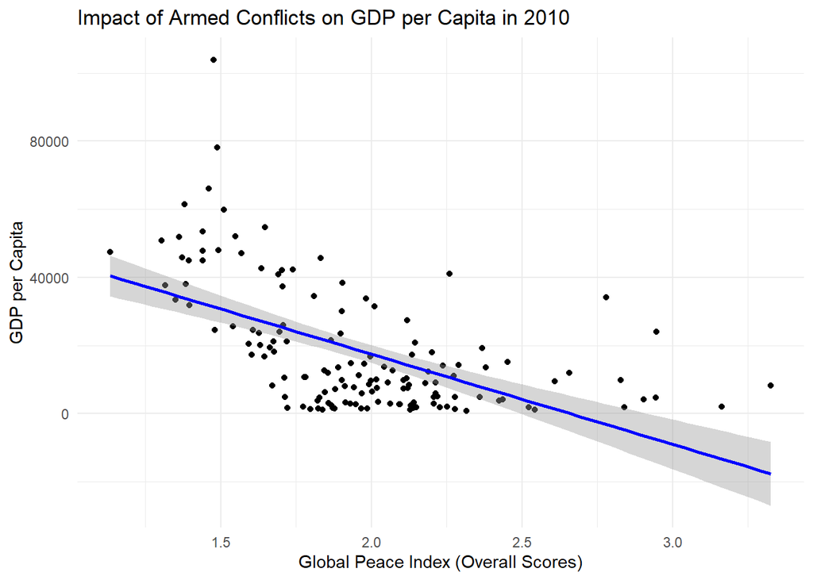

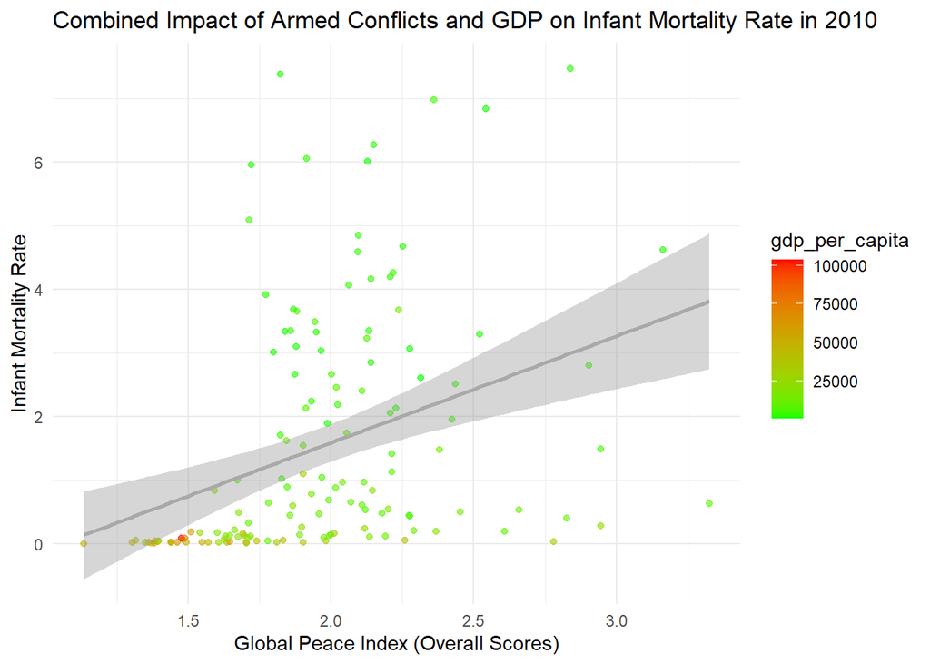

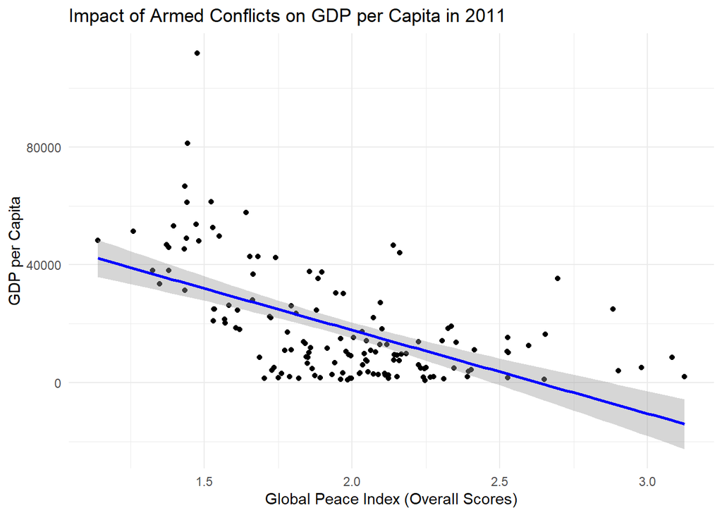

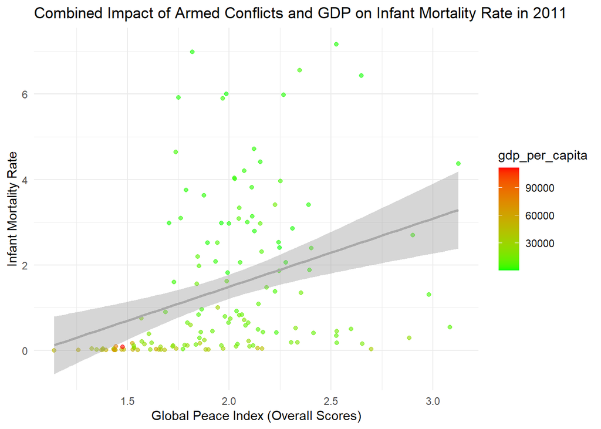

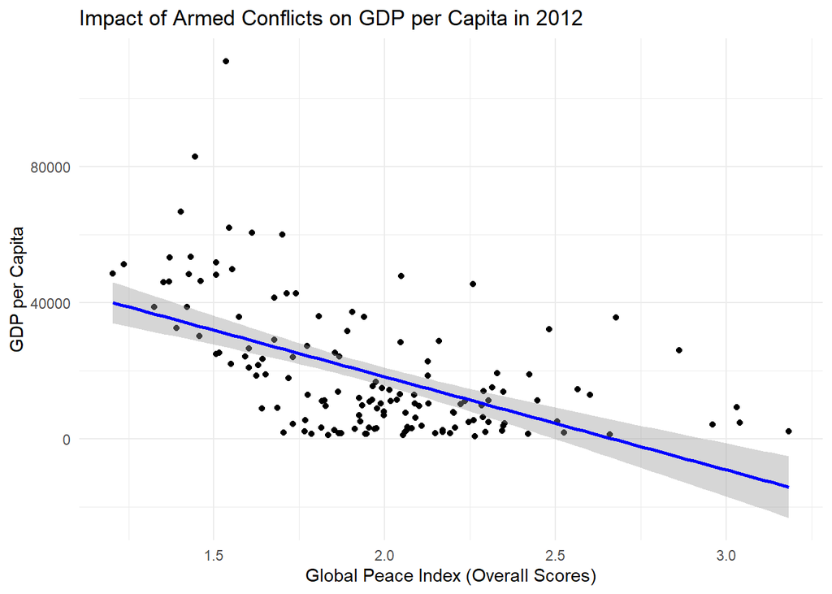

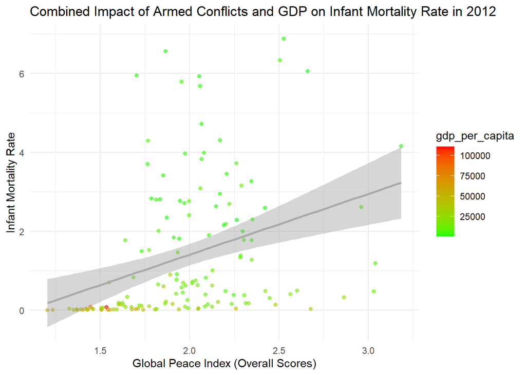

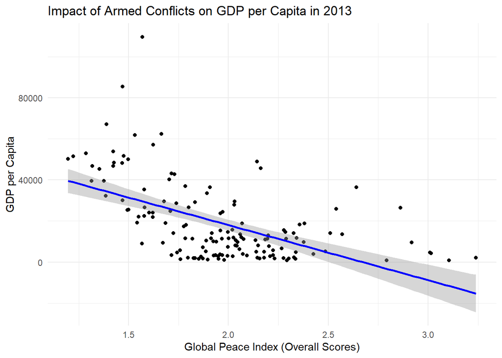

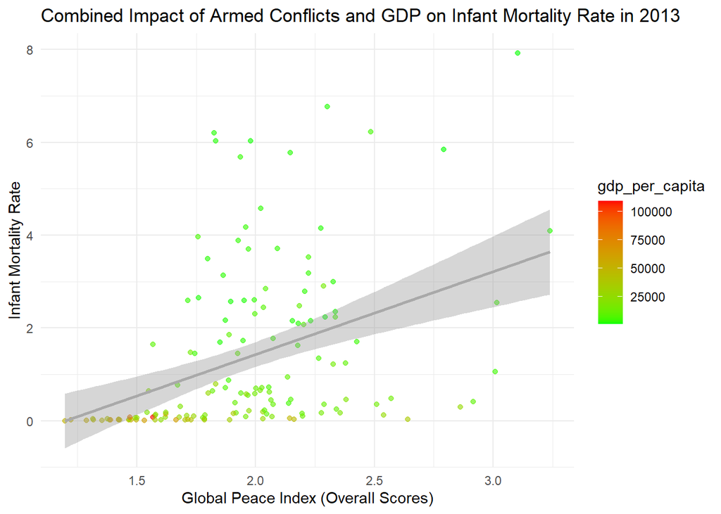

[12 more figures not shown]

Les graphiques obtenus montre comment le GPI et le PIB influencent conjointement le taux de mortalité infantile par pneumonie, avec une attention particulière sur la manière dont ces relations peuvent varier d’une année à l’autre. mais il présente aussi une anomalie évidente : la ligne de régression prédit des valeurs négatives pour le PIB par habitant à mesure que l’indice de paix global (GPI) augmente, ce qui n’est pas logique ni économiquement possible. Le PIB par habitant, qui mesure la prospérité économique moyenne d’une nation, ne peut pas être négatif. Cette situation pourrait être due l’utilisation inappropriée d’un modèle linéaire lorsque les données nécessitent un modèle non linéaire pour une représentation plus précise de la relation entre GPI et PIB.

**La matrice de corrélation**

```
##                          Overall_Scores gdp_per_capita Pneumonia_Mortality_Rate
## Overall_Scores                1.0000000     -0.5458209                0.3626806
## gdp_per_capita               -0.5458209      1.0000000               -0.5681749
## Pneumonia_Mortality_Rate      0.3626806     -0.5681749                1.0000000
```

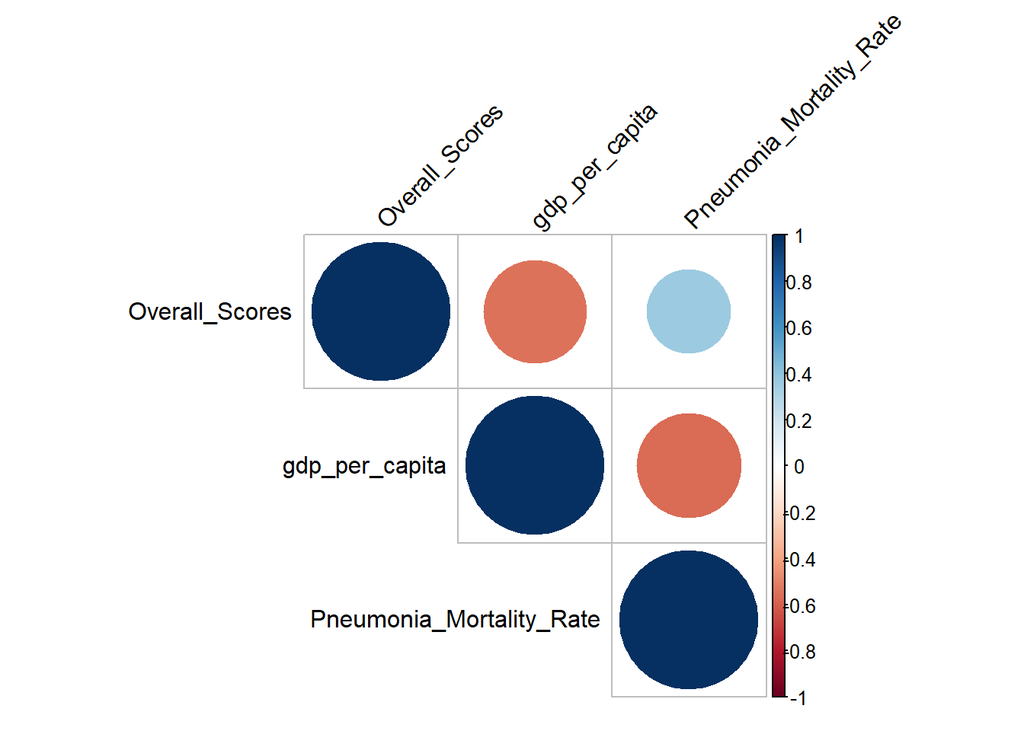

**Existe-il d’autres facteurs**

Cetta dernière partie sert de complément à notre étude, en introduisant des comparaisons aléatoires qui mettent en lumière des insights variés sur l’influence des conditions socio-économiques et des conflits sur la mortalité infantile par pneumonie.

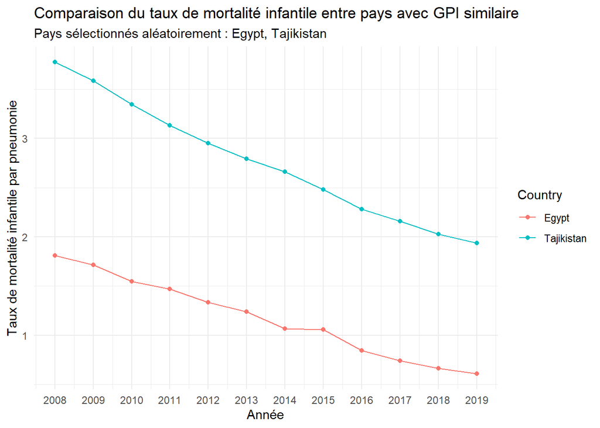

Cette visualisation sert de point de départ pour de plus amples recherches. Cette approche randomisée met en évidence la variation des tendances sanitaires même parmi les pays qui partagent des indices de paix comparables, suggérant que d’autres facteurs, tels que les politiques de santé, l’infrastructure, et les conditions socio-économiques, jouent un rôle crucial dans la santé des enfants. Les résultats encouragent une analyse plus nuancée des données, explorant comment et pourquoi ces différences existent, et quelles leçons peuvent être tirées pour améliorer la santé infantile au-delà des frontières géographiques et des classements de paix.

**Sources**

- Pneumonia — no child should die from a disease we can prevent
  - https://ourworldindata.org/child-deaths-from-pneumonia
- Childhood pneumonia in humanitarian emergencies in low- and middle-income countries: A systematic scoping review
  - https://jogh.org/2022/jogh-12-10001
- Uppsala Conflict Data Program
  - https://ucdp.uu.se/
- Chocs Économiques et Conflits Armés
  - https://ses.ens-lyon.fr/articles/chocs-economiques-et-conflits-armes
- Overall GPI Score
  - https://www.visionofhumanity.org/maps/#/